# Reproducible Research: Peer Assessment 1

## Loading and preprocessing the data

Data is located in the active directory, it is unzipped, loaded noting the NAs. Libraries needed to complete the analysis are also loaded at this time.

```r
unzip(zipfile="activity.zip")
data <- read.csv("activity.csv", na.strings = "NA")
library(dplyr)
library(ggvis)
library(lattice)
```

## What is mean total number of steps taken per day?

Ignoring NAs for now, we calculate the total number of steps per day and graph it as a histogram.

```r
processed <- data %>%
        group_by(date) %>%
        summarise(total = sum(steps, na.rm = TRUE))

processed %>% ggvis(~total) %>% layer_histograms(width = 1000, fill := "orangered") %>% add_axis("x", title = "Value") %>% add_axis("y", title = "Count")
```

[output not shown]

The mean number of steps per day is: 9354.23.

The median number of steps per day is: 10395.

## What is the average daily activity pattern?

Below is time series plot of the 5-minute intervals (x-axis) and the average number of steps taken, averaged across all days (y-axis).

```r
daily <- data %>%
        group_by(interval) %>%
        summarise(average = mean(steps, na.rm = TRUE))

daily %>% ggvis(~interval, ~average) %>% layer_lines(fill := "indigo")
```

[output not shown]

```r
most.active <- daily %>%
            mutate(rank = rank(desc(average))) %>%
            filter(rank == 1)
```

## Imputing missing values

The total number of NAs in the database is: 2304.

We’ll create a new dataset with the NAs filled in using the daily average for that interval.

```r
#copy data to new dataframe

data.impute = data

#do a loop to re-write the NAs

for (i in 1:length(data.impute$steps)){

  if(is.na(data.impute$steps[i]) == TRUE ) {

    data.impute$steps[i] = filter(daily, interval == data.impute$interval[i])$average

  }

}
```

Now that we’ve done that, let’s plot and re-think our analysis.

```r
impute.processed <- data.impute %>%
        group_by(date) %>%
        summarise(total = sum(steps, na.rm = TRUE))

impute.processed %>% ggvis(~total) %>% layer_histograms(width = 1000, fill := "FireBrick") %>% add_axis("x", title = "Value") %>% add_axis("y", title = "Count")
```

[output not shown]

## Are there differences in activity patterns between weekdays and weekends?

Now we’ll divide the data by weekday and weekend to see if there are differences in patterns.

```r
data.impute$dayofweek <-weekdays(as.Date(data.impute$date))
data.impute$day <- "Weekday"

for (i in 1:length(data.impute$dayofweek)) {
  if (data.impute$dayofweek[i] == "Saturday") {
    data.impute$day[i]<-"Weekend"
  }else if (data.impute$dayofweek[i] == "Sunday") {
    data.impute$day[i]<-"Weekend"
  }
}
```

Calculate our daily averages again.

```r
daily.impute.mean <- data.impute %>%
        group_by(interval, day) %>%
        summarise(average = mean(steps, na.rm = TRUE))
```

Now we plot the data.

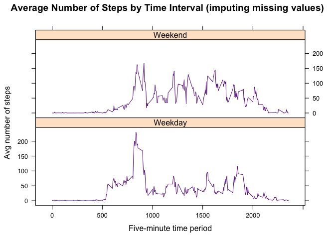

```r
xyplot(average ~ interval | as.factor(day), data = daily.impute.mean, type = "l", layout = c(1, 2), col = c("darkorchid4"), main = "Average Number of Steps by Time Interval (imputing missing values)", xlab = "Five-minute time period", ylab = "Avg number of steps")
```

Weekdays appear to have a morning spike in activity, followed by a more sedentary rest of day. Weekends appear to be more variable. They don’t have has large a spike, but the overall activity continues throughout the day.